# Risk Factor Analysis

## Outcome Variable

**Outcome Variable:** stunted

## Predictor Variables

**Intervention Variable:** enstunt

**Adjustment Set:**

- arm
- sex
- W_mage
- meducyrs
- feducyrs
- vagbrth
- single
- brthmon
- W_parity
- impsan
- delta_W_mage
- delta_meducyrs
- delta_feducyrs
- delta_vagbrth
- delta_single
- delta_brthmon
- delta_W_parity
- delta_impsan

## Stratifying Variables

The analysis was stratified on these variable(s):

- agecat
- studyid
- country

## Data Summary

| agecat | studyid | country | enstunt | stunted | n_cell | n |
| --- | --- | --- | --- | --- | --- | --- |
| Birth | CMC-V-BCS-2002 | INDIA | 0 | 0 | 75 | 92 |
| Birth | CMC-V-BCS-2002 | INDIA | 0 | 1 | 0 | 92 |
| Birth | CMC-V-BCS-2002 | INDIA | 1 | 0 | 0 | 92 |
| Birth | CMC-V-BCS-2002 | INDIA | 1 | 1 | 17 | 92 |
| Birth | CMIN | BANGLADESH | 0 | 0 | 17 | 26 |
| Birth | CMIN | BANGLADESH | 0 | 1 | 0 | 26 |
| Birth | CMIN | BANGLADESH | 1 | 0 | 0 | 26 |
| Birth | CMIN | BANGLADESH | 1 | 1 | 9 | 26 |
| Birth | COHORTS | GUATEMALA | 0 | 0 | 802 | 852 |
| Birth | COHORTS | GUATEMALA | 0 | 1 | 0 | 852 |
| Birth | COHORTS | GUATEMALA | 1 | 0 | 0 | 852 |
| Birth | COHORTS | GUATEMALA | 1 | 1 | 50 | 852 |
| Birth | COHORTS | INDIA | 0 | 0 | 5848 | 6640 |
| Birth | COHORTS | INDIA | 0 | 1 | 0 | 6640 |
| Birth | COHORTS | INDIA | 1 | 0 | 0 | 6640 |
| Birth | COHORTS | INDIA | 1 | 1 | 792 | 6640 |
| Birth | COHORTS | PHILIPPINES | 0 | 0 | 2863 | 3050 |
| Birth | COHORTS | PHILIPPINES | 0 | 1 | 0 | 3050 |
| Birth | COHORTS | PHILIPPINES | 1 | 0 | 0 | 3050 |
| Birth | COHORTS | PHILIPPINES | 1 | 1 | 187 | 3050 |
| Birth | CONTENT | PERU | 0 | 0 | 2 | 2 |
| Birth | CONTENT | PERU | 0 | 1 | 0 | 2 |
| Birth | CONTENT | PERU | 1 | 0 | 0 | 2 |
| Birth | CONTENT | PERU | 1 | 1 | 0 | 2 |
| Birth | EE | PAKISTAN | 0 | 0 | 140 | 240 |
| Birth | EE | PAKISTAN | 0 | 1 | 0 | 240 |
| Birth | EE | PAKISTAN | 1 | 0 | 0 | 240 |
| Birth | EE | PAKISTAN | 1 | 1 | 100 | 240 |
| Birth | GMS-Nepal | NEPAL | 0 | 0 | 574 | 696 |
| Birth | GMS-Nepal | NEPAL | 0 | 1 | 0 | 696 |

[output cut: 298 more lines]

The following strata were considered:

- agecat: 24 months, studyid: CMC-V-BCS-2002, country: INDIA
- agecat: 24 months, studyid: CMIN, country: BANGLADESH
- agecat: 24 months, studyid: COHORTS, country: GUATEMALA
- agecat: 24 months, studyid: COHORTS, country: INDIA
- agecat: 24 months, studyid: COHORTS, country: PHILIPPINES
- agecat: 24 months, studyid: CONTENT, country: PERU
- agecat: 24 months, studyid: EE, country: PAKISTAN
- agecat: 24 months, studyid: GMS-Nepal, country: NEPAL
- agecat: 24 months, studyid: IRC, country: INDIA
- agecat: 24 months, studyid: JiVitA-3, country: BANGLADESH
- agecat: 24 months, studyid: JiVitA-4, country: BANGLADESH
- agecat: 24 months, studyid: Keneba, country: GAMBIA
- agecat: 24 months, studyid: LCNI-5, country: MALAWI
- agecat: 24 months, studyid: MAL-ED, country: BANGLADESH
- agecat: 24 months, studyid: MAL-ED, country: BRAZIL
- agecat: 24 months, studyid: MAL-ED, country: INDIA
- agecat: 24 months, studyid: MAL-ED, country: NEPAL
- agecat: 24 months, studyid: MAL-ED, country: PERU
- agecat: 24 months, studyid: MAL-ED, country: SOUTH AFRICA
- agecat: 24 months, studyid: MAL-ED, country: TANZANIA, UNITED REPUBLIC OF
- agecat: 24 months, studyid: NIH-Birth, country: BANGLADESH
- agecat: 24 months, studyid: NIH-Crypto, country: BANGLADESH
- agecat: 24 months, studyid: PROBIT, country: BELARUS
- agecat: 24 months, studyid: PROVIDE, country: BANGLADESH
- agecat: 24 months, studyid: TanzaniaChild2, country: TANZANIA, UNITED REPUBLIC OF
- agecat: 24 months, studyid: ZVITAMBO, country: ZIMBABWE
- agecat: 6 months, studyid: CMC-V-BCS-2002, country: INDIA
- agecat: 6 months, studyid: CMIN, country: BANGLADESH
- agecat: 6 months, studyid: COHORTS, country: GUATEMALA
- agecat: 6 months, studyid: COHORTS, country: INDIA
- agecat: 6 months, studyid: COHORTS, country: PHILIPPINES
- agecat: 6 months, studyid: CONTENT, country: PERU
- agecat: 6 months, studyid: EE, country: PAKISTAN
- agecat: 6 months, studyid: GMS-Nepal, country: NEPAL
- agecat: 6 months, studyid: Guatemala BSC, country: GUATEMALA
- agecat: 6 months, studyid: IRC, country: INDIA
- agecat: 6 months, studyid: JiVitA-3, country: BANGLADESH
- agecat: 6 months, studyid: JiVitA-4, country: BANGLADESH
- agecat: 6 months, studyid: Keneba, country: GAMBIA
- agecat: 6 months, studyid: LCNI-5, country: MALAWI
- agecat: 6 months, studyid: MAL-ED, country: BANGLADESH
- agecat: 6 months, studyid: MAL-ED, country: BRAZIL
- agecat: 6 months, studyid: MAL-ED, country: INDIA
- agecat: 6 months, studyid: MAL-ED, country: NEPAL
- agecat: 6 months, studyid: MAL-ED, country: PERU
- agecat: 6 months, studyid: MAL-ED, country: SOUTH AFRICA
- agecat: 6 months, studyid: MAL-ED, country: TANZANIA, UNITED REPUBLIC OF
- agecat: 6 months, studyid: NIH-Birth, country: BANGLADESH
- agecat: 6 months, studyid: NIH-Crypto, country: BANGLADESH
- agecat: 6 months, studyid: PROBIT, country: BELARUS
- agecat: 6 months, studyid: PROVIDE, country: BANGLADESH
- agecat: 6 months, studyid: ResPak, country: PAKISTAN
- agecat: 6 months, studyid: SAS-CompFeed, country: INDIA
- agecat: 6 months, studyid: SAS-FoodSuppl, country: INDIA
- agecat: 6 months, studyid: TanzaniaChild2, country: TANZANIA, UNITED REPUBLIC OF
- agecat: 6 months, studyid: ZVITAMBO, country: ZIMBABWE
- agecat: Birth, studyid: CMC-V-BCS-2002, country: INDIA
- agecat: Birth, studyid: CMIN, country: BANGLADESH
- agecat: Birth, studyid: COHORTS, country: GUATEMALA
- agecat: Birth, studyid: COHORTS, country: INDIA
- agecat: Birth, studyid: COHORTS, country: PHILIPPINES
- agecat: Birth, studyid: CONTENT, country: PERU
- agecat: Birth, studyid: EE, country: PAKISTAN
- agecat: Birth, studyid: GMS-Nepal, country: NEPAL
- agecat: Birth, studyid: IRC, country: INDIA
- agecat: Birth, studyid: JiVitA-3, country: BANGLADESH
- agecat: Birth, studyid: JiVitA-4, country: BANGLADESH
- agecat: Birth, studyid: Keneba, country: GAMBIA
- agecat: Birth, studyid: MAL-ED, country: BANGLADESH
- agecat: Birth, studyid: MAL-ED, country: BRAZIL
- agecat: Birth, studyid: MAL-ED, country: INDIA
- agecat: Birth, studyid: MAL-ED, country: NEPAL
- agecat: Birth, studyid: MAL-ED, country: PERU
- agecat: Birth, studyid: MAL-ED, country: SOUTH AFRICA
- agecat: Birth, studyid: MAL-ED, country: TANZANIA, UNITED REPUBLIC OF
- agecat: Birth, studyid: NIH-Birth, country: BANGLADESH
- agecat: Birth, studyid: NIH-Crypto, country: BANGLADESH
- agecat: Birth, studyid: PROBIT, country: BELARUS
- agecat: Birth, studyid: PROVIDE, country: BANGLADESH
- agecat: Birth, studyid: ResPak, country: PAKISTAN
- agecat: Birth, studyid: SAS-CompFeed, country: INDIA
- agecat: Birth, studyid: ZVITAMBO, country: ZIMBABWE

### Dropped Strata

Some strata were dropped due to rare outcomes:

- agecat: Birth, studyid: CMC-V-BCS-2002, country: INDIA
- agecat: Birth, studyid: CMIN, country: BANGLADESH
- agecat: Birth, studyid: COHORTS, country: GUATEMALA
- agecat: Birth, studyid: COHORTS, country: INDIA
- agecat: Birth, studyid: COHORTS, country: PHILIPPINES
- agecat: Birth, studyid: CONTENT, country: PERU
- agecat: Birth, studyid: EE, country: PAKISTAN
- agecat: Birth, studyid: GMS-Nepal, country: NEPAL
- agecat: Birth, studyid: IRC, country: INDIA
- agecat: Birth, studyid: JiVitA-3, country: BANGLADESH
- agecat: Birth, studyid: JiVitA-4, country: BANGLADESH
- agecat: Birth, studyid: Keneba, country: GAMBIA
- agecat: Birth, studyid: MAL-ED, country: BANGLADESH
- agecat: Birth, studyid: MAL-ED, country: BRAZIL
- agecat: Birth, studyid: MAL-ED, country: INDIA
- agecat: Birth, studyid: MAL-ED, country: NEPAL
- agecat: Birth, studyid: MAL-ED, country: PERU
- agecat: Birth, studyid: MAL-ED, country: SOUTH AFRICA
- agecat: Birth, studyid: MAL-ED, country: TANZANIA, UNITED REPUBLIC OF
- agecat: Birth, studyid: NIH-Birth, country: BANGLADESH
- agecat: Birth, studyid: NIH-Crypto, country: BANGLADESH
- agecat: Birth, studyid: PROBIT, country: BELARUS
- agecat: Birth, studyid: PROVIDE, country: BANGLADESH
- agecat: Birth, studyid: ResPak, country: PAKISTAN
- agecat: Birth, studyid: SAS-CompFeed, country: INDIA
- agecat: Birth, studyid: ZVITAMBO, country: ZIMBABWE
- agecat: 6 months, studyid: CONTENT, country: PERU
- agecat: 6 months, studyid: LCNI-5, country: MALAWI
- agecat: 6 months, studyid: MAL-ED, country: BRAZIL
- agecat: 6 months, studyid: MAL-ED, country: NEPAL
- agecat: 24 months, studyid: MAL-ED, country: BRAZIL
- agecat: 24 months, studyid: MAL-ED, country: TANZANIA, UNITED REPUBLIC OF
- agecat: 24 months, studyid: PROBIT, country: BELARUS
- agecat: 24 months, studyid: TanzaniaChild2, country: TANZANIA, UNITED REPUBLIC OF

## Methods Detail

We’re interested in the causal parameters $E[Y_a]$ for all values of $a \in \mathcal{A}$. These parameters represent the mean outcome if, possibly contrary to fact, we intervened to set all units to have $A=a$. Under the randomization and positivity assumptions, these are identified by the statistical parameters $\psi_a=E_W[E_{Y|A,W}(Y|A=a,W)]$. In addition, we’re interested in the mean of $Y$, $E[Y]$ under no intervention (the observed mean). We will estimate these parameters by using SuperLearner to fit the relevant likelihood factors – $E_{Y|A,W}(Y|A=a,W)$ and $p(A=a|W)$, and then updating our likelihood fit using a joint TMLE.

For unadjusted analyses ($W=\{\}$), initial likelihoods were estimated using Lrnr_glm to estimate the simple $E(Y|A)$ and Lrnr_mean to estimate $p(A)$. For adjusted analyses, a small library containing Lrnr_glmnet, Lrnr_xgboost, and Lrnr_mean was used.

Having estimated these parameters, we will then use the delta method to estimate relative risks and attributable risks relative to a prespecified baseline level of $A$.

# Results Detail

## Results Plots

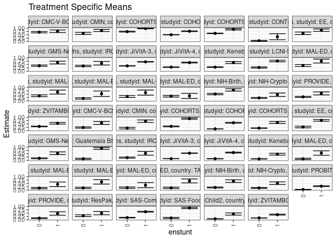

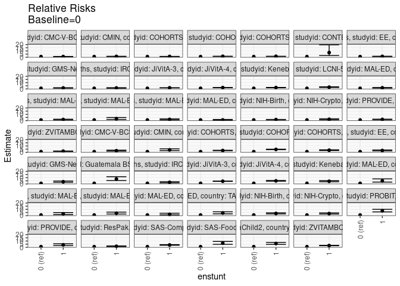

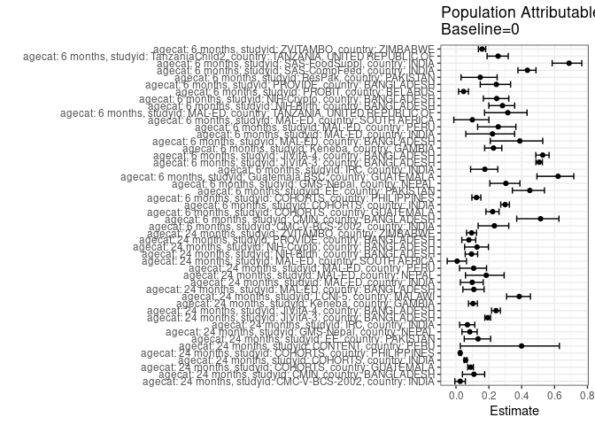

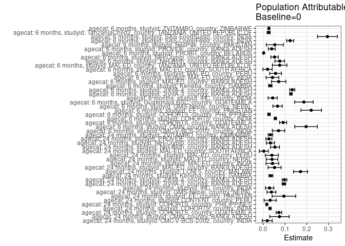

## Results Table

### Parameter: TSM

| agecat | studyid | country | intervention_level | baseline_level | estimate | ci_lower | ci_upper |
| --- | --- | --- | --- | --- | --- | --- | --- |
| 6 months | CMC-V-BCS-2002 | INDIA | 0 | NA | 0.2305236 | 0.1822375 | 0.2788098 |
| 6 months | CMC-V-BCS-2002 | INDIA | 1 | NA | 0.5778780 | 0.4643470 | 0.6914090 |
| 6 months | CMIN | BANGLADESH | 0 | NA | 0.1856694 | 0.1235702 | 0.2477686 |
| 6 months | CMIN | BANGLADESH | 1 | NA | 0.7117479 | 0.6195921 | 0.8039038 |
| 6 months | COHORTS | GUATEMALA | 0 | NA | 0.3185005 | 0.2863432 | 0.3506578 |
| 6 months | COHORTS | GUATEMALA | 1 | NA | 0.9017714 | 0.8560507 | 0.9474921 |
| 6 months | COHORTS | INDIA | 0 | NA | 0.1299371 | 0.1214945 | 0.1383796 |
| 6 months | COHORTS | INDIA | 1 | NA | 0.5917881 | 0.5588125 | 0.6247638 |
| 6 months | COHORTS | PHILIPPINES | 0 | NA | 0.1849315 | 0.1698809 | 0.1999822 |
| 6 months | COHORTS | PHILIPPINES | 1 | NA | 0.6114979 | 0.5351913 | 0.6878045 |
| 6 months | EE | PAKISTAN | 0 | NA | 0.2701133 | 0.2088214 | 0.3314051 |
| 6 months | EE | PAKISTAN | 1 | NA | 0.7699868 | 0.7047173 | 0.8352564 |
| 6 months | GMS-Nepal | NEPAL | 0 | NA | 0.1506490 | 0.1184102 | 0.1828878 |
| 6 months | GMS-Nepal | NEPAL | 1 | NA | 0.5340031 | 0.4300166 | 0.6379896 |
| 6 months | Guatemala BSC | GUATEMALA | 0 | NA | 0.1140351 | 0.0727079 | 0.1553623 |
| 6 months | Guatemala BSC | GUATEMALA | 1 | NA | 0.9014085 | 0.8319497 | 0.9708672 |
| 6 months | IRC | INDIA | 0 | NA | 0.2025367 | 0.1607396 | 0.2443337 |
| 6 months | IRC | INDIA | 1 | NA | 0.5297495 | 0.3876710 | 0.6718281 |
| 6 months | JiVitA-3 | BANGLADESH | 0 | NA | 0.1240370 | 0.1170287 | 0.1310453 |
| 6 months | JiVitA-3 | BANGLADESH | 1 | NA | 0.5378637 | 0.5223367 | 0.5533908 |
| 6 months | JiVitA-4 | BANGLADESH | 0 | NA | 0.1193465 | 0.1062215 | 0.1324715 |
| 6 months | JiVitA-4 | BANGLADESH | 1 | NA | 0.5859418 | 0.5549250 | 0.6169587 |
| 6 months | Keneba | GAMBIA | 0 | NA | 0.1089534 | 0.0948953 | 0.1230114 |
| 6 months | Keneba | GAMBIA | 1 | NA | 0.4622937 | 0.3907133 | 0.5338741 |
| 6 months | MAL-ED | BANGLADESH | 0 | NA | 0.1115914 | 0.0683683 | 0.1548144 |
| 6 months | MAL-ED | BANGLADESH | 1 | NA | 0.5490900 | 0.3816389 | 0.7165411 |
| 6 months | MAL-ED | INDIA | 0 | NA | 0.1482745 | 0.0985391 | 0.1980100 |
| 6 months | MAL-ED | INDIA | 1 | NA | 0.4295465 | 0.2539505 | 0.6051425 |
| 6 months | MAL-ED | PERU | 0 | NA | 0.1632659 | 0.1162971 | 0.2102347 |
| 6 months | MAL-ED | PERU | 1 | NA | 0.6145755 | 0.4476072 | 0.7815438 |

[output cut: 66 more lines]

### Parameter: E(Y)

| agecat | studyid | country | intervention_level | baseline_level | estimate | ci_lower | ci_upper |
| --- | --- | --- | --- | --- | --- | --- | --- |
| 6 months | CMC-V-BCS-2002 | INDIA | NA | NA | 0.3008130 | 0.2539566 | 0.3476694 |
| 6 months | CMIN | BANGLADESH | NA | NA | 0.3827160 | 0.3214780 | 0.4439541 |
| 6 months | COHORTS | GUATEMALA | NA | NA | 0.4099896 | 0.3788775 | 0.4411017 |
| 6 months | COHORTS | INDIA | NA | NA | 0.1854227 | 0.1762253 | 0.1946201 |
| 6 months | COHORTS | PHILIPPINES | NA | NA | 0.2112260 | 0.1958496 | 0.2266024 |
| 6 months | EE | PAKISTAN | NA | NA | 0.4906166 | 0.4398159 | 0.5414174 |
| 6 months | GMS-Nepal | NEPAL | NA | NA | 0.2163121 | 0.1823021 | 0.2503220 |
| 6 months | Guatemala BSC | GUATEMALA | NA | NA | 0.3010033 | 0.2489243 | 0.3530824 |
| 6 months | IRC | INDIA | NA | NA | 0.2457002 | 0.2038248 | 0.2875757 |
| 6 months | JiVitA-3 | BANGLADESH | NA | NA | 0.2513830 | 0.2432594 | 0.2595066 |
| 6 months | JiVitA-4 | BANGLADESH | NA | NA | 0.2527427 | 0.2386864 | 0.2667990 |
| 6 months | Keneba | GAMBIA | NA | NA | 0.1412159 | 0.1262788 | 0.1561530 |
| 6 months | MAL-ED | BANGLADESH | NA | NA | 0.1825726 | 0.1336978 | 0.2314474 |
| 6 months | MAL-ED | INDIA | NA | NA | 0.1906780 | 0.1404524 | 0.2409036 |
| 6 months | MAL-ED | PERU | NA | NA | 0.2197802 | 0.1705687 | 0.2689917 |
| 6 months | MAL-ED | SOUTH AFRICA | NA | NA | 0.1968504 | 0.1478551 | 0.2458457 |
| 6 months | MAL-ED | TANZANIA, UNITED REPUBLIC OF | NA | NA | 0.2388664 | 0.1855834 | 0.2921494 |
| 6 months | NIH-Birth | BANGLADESH | NA | NA | 0.2681564 | 0.2306532 | 0.3056597 |
| 6 months | NIH-Crypto | BANGLADESH | NA | NA | 0.2097902 | 0.1799252 | 0.2396552 |
| 6 months | PROBIT | BELARUS | NA | NA | 0.0393401 | 0.0293640 | 0.0493162 |
| 6 months | PROVIDE | BANGLADESH | NA | NA | 0.1589404 | 0.1297581 | 0.1881227 |
| 6 months | ResPak | PAKISTAN | NA | NA | 0.3598326 | 0.2988570 | 0.4208083 |
| 6 months | SAS-CompFeed | INDIA | NA | NA | 0.2844311 | 0.2666491 | 0.3022132 |
| 6 months | SAS-FoodSuppl | INDIA | NA | NA | 0.4289474 | 0.3791199 | 0.4787748 |
| 6 months | TanzaniaChild2 | TANZANIA, UNITED REPUBLIC OF | NA | NA | 0.0970922 | 0.0842059 | 0.1099785 |
| 6 months | ZVITAMBO | ZIMBABWE | NA | NA | 0.1628792 | 0.1551057 | 0.1706527 |
| 24 months | CMC-V-BCS-2002 | INDIA | NA | NA | 0.7169811 | 0.6710815 | 0.7628807 |
| 24 months | CMIN | BANGLADESH | NA | NA | 0.6818182 | 0.6230135 | 0.7406228 |
| 24 months | COHORTS | GUATEMALA | NA | NA | 0.8112150 | 0.7877559 | 0.8346740 |
| 24 months | COHORTS | INDIA | NA | NA | 0.5351321 | 0.5217497 | 0.5485145 |
| 24 months | COHORTS | PHILIPPINES | NA | NA | 0.6229039 | 0.6036892 | 0.6421186 |
| 24 months | CONTENT | PERU | NA | NA | 0.0792683 | 0.0377948 | 0.1207418 |
| 24 months | EE | PAKISTAN | NA | NA | 0.7065868 | 0.6373214 | 0.7758523 |
| 24 months | GMS-Nepal | NEPAL | NA | NA | 0.4487705 | 0.4045970 | 0.4929440 |
| 24 months | IRC | INDIA | NA | NA | 0.4205379 | 0.3726382 | 0.4684376 |
| 24 months | JiVitA-3 | BANGLADESH | NA | NA | 0.4910797 | 0.4779658 | 0.5041936 |
| 24 months | JiVitA-4 | BANGLADESH | NA | NA | 0.4008838 | 0.3839145 | 0.4178532 |
| 24 months | Keneba | GAMBIA | NA | NA | 0.3368116 | 0.3145020 | 0.3591212 |
| 24 months | LCNI-5 | MALAWI | NA | NA | 0.4455959 | 0.4050760 | 0.4861157 |
| 24 months | MAL-ED | BANGLADESH | NA | NA | 0.4764151 | 0.4090254 | 0.5438047 |
| 24 months | MAL-ED | INDIA | NA | NA | 0.4273128 | 0.3628178 | 0.4918077 |
| 24 months | MAL-ED | NEPAL | NA | NA | 0.2192982 | 0.1654718 | 0.2731246 |
| 24 months | MAL-ED | PERU | NA | NA | 0.3681592 | 0.3013164 | 0.4350020 |
| 24 months | MAL-ED | SOUTH AFRICA | NA | NA | 0.3529412 | 0.2921001 | 0.4137823 |
| 24 months | NIH-Birth | BANGLADESH | NA | NA | 0.5687646 | 0.5218455 | 0.6156837 |
| 24 months | NIH-Crypto | BANGLADESH | NA | NA | 0.2568093 | 0.2190047 | 0.2946140 |
| 24 months | PROVIDE | BANGLADESH | NA | NA | 0.3287197 | 0.2903909 | 0.3670485 |
| 24 months | ZVITAMBO | ZIMBABWE | NA | NA | 0.3469512 | 0.3239068 | 0.3699956 |

### Parameter: RR

| agecat | studyid | country | intervention_level | baseline_level | estimate | ci_lower | ci_upper |
| --- | --- | --- | --- | --- | --- | --- | --- |
| 6 months | CMC-V-BCS-2002 | INDIA | 0 | 0 | 1.000000 | 1.0000000 | 1.000000 |
| 6 months | CMC-V-BCS-2002 | INDIA | 1 | 0 | 2.506806 | 1.8802669 | 3.342119 |
| 6 months | CMIN | BANGLADESH | 0 | 0 | 1.000000 | 1.0000000 | 1.000000 |
| 6 months | CMIN | BANGLADESH | 1 | 0 | 3.833416 | 2.6884746 | 5.465954 |
| 6 months | COHORTS | GUATEMALA | 0 | 0 | 1.000000 | 1.0000000 | 1.000000 |
| 6 months | COHORTS | GUATEMALA | 1 | 0 | 2.831303 | 2.5288523 | 3.169926 |
| 6 months | COHORTS | INDIA | 0 | 0 | 1.000000 | 1.0000000 | 1.000000 |
| 6 months | COHORTS | INDIA | 1 | 0 | 4.554422 | 4.1828630 | 4.958986 |
| 6 months | COHORTS | PHILIPPINES | 0 | 0 | 1.000000 | 1.0000000 | 1.000000 |
| 6 months | COHORTS | PHILIPPINES | 1 | 0 | 3.306618 | 2.8502353 | 3.836078 |
| 6 months | EE | PAKISTAN | 0 | 0 | 1.000000 | 1.0000000 | 1.000000 |
| 6 months | EE | PAKISTAN | 1 | 0 | 2.850607 | 2.2347931 | 3.636113 |
| 6 months | GMS-Nepal | NEPAL | 0 | 0 | 1.000000 | 1.0000000 | 1.000000 |
| 6 months | GMS-Nepal | NEPAL | 1 | 0 | 3.544684 | 2.6527328 | 4.736545 |
| 6 months | Guatemala BSC | GUATEMALA | 0 | 0 | 1.000000 | 1.0000000 | 1.000000 |
| 6 months | Guatemala BSC | GUATEMALA | 1 | 0 | 7.904659 | 5.4572418 | 11.449672 |
| 6 months | IRC | INDIA | 0 | 0 | 1.000000 | 1.0000000 | 1.000000 |
| 6 months | IRC | INDIA | 1 | 0 | 2.615573 | 1.8639587 | 3.670266 |
| 6 months | JiVitA-3 | BANGLADESH | 0 | 0 | 1.000000 | 1.0000000 | 1.000000 |
| 6 months | JiVitA-3 | BANGLADESH | 1 | 0 | 4.336317 | 4.0881094 | 4.599595 |
| 6 months | JiVitA-4 | BANGLADESH | 0 | 0 | 1.000000 | 1.0000000 | 1.000000 |
| 6 months | JiVitA-4 | BANGLADESH | 1 | 0 | 4.909586 | 4.3313842 | 5.564973 |
| 6 months | Keneba | GAMBIA | 0 | 0 | 1.000000 | 1.0000000 | 1.000000 |
| 6 months | Keneba | GAMBIA | 1 | 0 | 4.243042 | 3.4690619 | 5.189705 |
| 6 months | MAL-ED | BANGLADESH | 0 | 0 | 1.000000 | 1.0000000 | 1.000000 |
| 6 months | MAL-ED | BANGLADESH | 1 | 0 | 4.920542 | 3.0068592 | 8.052168 |
| 6 months | MAL-ED | INDIA | 0 | 0 | 1.000000 | 1.0000000 | 1.000000 |
| 6 months | MAL-ED | INDIA | 1 | 0 | 2.896968 | 1.7068007 | 4.917048 |
| 6 months | MAL-ED | PERU | 0 | 0 | 1.000000 | 1.0000000 | 1.000000 |
| 6 months | MAL-ED | PERU | 1 | 0 | 3.764261 | 2.5438686 | 5.570124 |

[output cut: 66 more lines]

### Parameter: PAR

| agecat | studyid | country | intervention_level | baseline_level | estimate | ci_lower | ci_upper |
| --- | --- | --- | --- | --- | --- | --- | --- |
| 6 months | CMC-V-BCS-2002 | INDIA | 0 | NA | 0.0702894 | 0.0416285 | 0.0989503 |
| 6 months | CMIN | BANGLADESH | 0 | NA | 0.1970467 | 0.1449748 | 0.2491185 |
| 6 months | COHORTS | GUATEMALA | 0 | NA | 0.0914891 | 0.0752796 | 0.1076985 |
| 6 months | COHORTS | INDIA | 0 | NA | 0.0554857 | 0.0500873 | 0.0608841 |
| 6 months | COHORTS | PHILIPPINES | 0 | NA | 0.0262945 | 0.0203566 | 0.0322323 |
| 6 months | EE | PAKISTAN | 0 | NA | 0.2205033 | 0.1733229 | 0.2676838 |
| 6 months | GMS-Nepal | NEPAL | 0 | NA | 0.0656631 | 0.0443366 | 0.0869895 |
| 6 months | Guatemala BSC | GUATEMALA | 0 | NA | 0.1869683 | 0.1443605 | 0.2295760 |
| 6 months | IRC | INDIA | 0 | NA | 0.0431636 | 0.0223193 | 0.0640078 |
| 6 months | JiVitA-3 | BANGLADESH | 0 | NA | 0.1273460 | 0.1216487 | 0.1330433 |
| 6 months | JiVitA-4 | BANGLADESH | 0 | NA | 0.1333962 | 0.1219249 | 0.1448676 |
| 6 months | Keneba | GAMBIA | 0 | NA | 0.0322625 | 0.0243372 | 0.0401879 |
| 6 months | MAL-ED | BANGLADESH | 0 | NA | 0.0709813 | 0.0378283 | 0.1041342 |
| 6 months | MAL-ED | INDIA | 0 | NA | 0.0424034 | 0.0128515 | 0.0719554 |
| 6 months | MAL-ED | PERU | 0 | NA | 0.0565143 | 0.0294344 | 0.0835942 |
| 6 months | MAL-ED | SOUTH AFRICA | 0 | NA | 0.0196289 | -0.0016536 | 0.0409115 |
| 6 months | MAL-ED | TANZANIA, UNITED REPUBLIC OF | 0 | NA | 0.0753385 | 0.0422218 | 0.1084552 |
| 6 months | NIH-Birth | BANGLADESH | 0 | NA | 0.0758440 | 0.0535849 | 0.0981031 |
| 6 months | NIH-Crypto | BANGLADESH | 0 | NA | 0.0520156 | 0.0348093 | 0.0692219 |
| 6 months | PROBIT | BELARUS | 0 | NA | 0.0018160 | 0.0007000 | 0.0029321 |
| 6 months | PROVIDE | BANGLADESH | 0 | NA | 0.0390278 | 0.0232292 | 0.0548264 |
| 6 months | ResPak | PAKISTAN | 0 | NA | 0.0531038 | 0.0137432 | 0.0924644 |
| 6 months | SAS-CompFeed | INDIA | 0 | NA | 0.1236007 | 0.1074898 | 0.1397115 |
| 6 months | SAS-FoodSuppl | INDIA | 0 | NA | 0.2952348 | 0.2495783 | 0.3408913 |
| 6 months | TanzaniaChild2 | TANZANIA, UNITED REPUBLIC OF | 0 | NA | 0.0248836 | 0.0179442 | 0.0318230 |
| 6 months | ZVITAMBO | ZIMBABWE | 0 | NA | 0.0258868 | 0.0221495 | 0.0296241 |
| 24 months | CMC-V-BCS-2002 | INDIA | 0 | NA | 0.0183123 | -0.0045315 | 0.0411561 |
| 24 months | CMIN | BANGLADESH | 0 | NA | 0.0745803 | 0.0299055 | 0.1192552 |
| 24 months | COHORTS | GUATEMALA | 0 | NA | 0.0720258 | 0.0591228 | 0.0849288 |
| 24 months | COHORTS | INDIA | 0 | NA | 0.0312460 | 0.0266784 | 0.0358136 |
| 24 months | COHORTS | PHILIPPINES | 0 | NA | 0.0160635 | 0.0120156 | 0.0201114 |
| 24 months | CONTENT | PERU | 0 | NA | 0.0316492 | 0.0038132 | 0.0594853 |
| 24 months | EE | PAKISTAN | 0 | NA | 0.0948973 | 0.0404893 | 0.1493053 |
| 24 months | GMS-Nepal | NEPAL | 0 | NA | 0.0376209 | 0.0171170 | 0.0581247 |
| 24 months | IRC | INDIA | 0 | NA | 0.0292018 | 0.0099387 | 0.0484649 |
| 24 months | JiVitA-3 | BANGLADESH | 0 | NA | 0.0949047 | 0.0867226 | 0.1030869 |
| 24 months | JiVitA-4 | BANGLADESH | 0 | NA | 0.0977450 | 0.0871214 | 0.1083686 |
| 24 months | Keneba | GAMBIA | 0 | NA | 0.0348314 | 0.0257362 | 0.0439266 |
| 24 months | LCNI-5 | MALAWI | 0 | NA | 0.1714420 | 0.1391527 | 0.2037314 |
| 24 months | MAL-ED | BANGLADESH | 0 | NA | 0.0518341 | 0.0216109 | 0.0820572 |
| 24 months | MAL-ED | INDIA | 0 | NA | 0.0422166 | 0.0129021 | 0.0715311 |
| 24 months | MAL-ED | NEPAL | 0 | NA | 0.0403163 | 0.0137251 | 0.0669075 |
| 24 months | MAL-ED | PERU | 0 | NA | 0.0395908 | 0.0094662 | 0.0697154 |
| 24 months | MAL-ED | SOUTH AFRICA | 0 | NA | 0.0024739 | -0.0181585 | 0.0231063 |
| 24 months | NIH-Birth | BANGLADESH | 0 | NA | 0.0538059 | 0.0330099 | 0.0746019 |
| 24 months | NIH-Crypto | BANGLADESH | 0 | NA | 0.0328585 | 0.0140486 | 0.0516685 |
| 24 months | PROVIDE | BANGLADESH | 0 | NA | 0.0258662 | 0.0120173 | 0.0397150 |
| 24 months | ZVITAMBO | ZIMBABWE | 0 | NA | 0.0330050 | 0.0225218 | 0.0434882 |

### Parameter: PAF

| agecat | studyid | country | intervention_level | baseline_level | estimate | ci_lower | ci_upper |
| --- | --- | --- | --- | --- | --- | --- | --- |
| 6 months | CMC-V-BCS-2002 | INDIA | 0 | NA | 0.2336647 | 0.1348851 | 0.3211656 |
| 6 months | CMIN | BANGLADESH | 0 | NA | 0.5148639 | 0.3696281 | 0.6266378 |
| 6 months | COHORTS | GUATEMALA | 0 | NA | 0.2231498 | 0.1822490 | 0.2620048 |
| 6 months | COHORTS | INDIA | 0 | NA | 0.2992389 | 0.2723069 | 0.3251741 |
| 6 months | COHORTS | PHILIPPINES | 0 | NA | 0.1244851 | 0.0967350 | 0.1513826 |
| 6 months | EE | PAKISTAN | 0 | NA | 0.4494412 | 0.3431016 | 0.5385665 |
| 6 months | GMS-Nepal | NEPAL | 0 | NA | 0.3035572 | 0.2063117 | 0.3888878 |
| 6 months | Guatemala BSC | GUATEMALA | 0 | NA | 0.6211501 | 0.4925719 | 0.7171476 |
| 6 months | IRC | INDIA | 0 | NA | 0.1756758 | 0.0888800 | 0.2542032 |
| 6 months | JiVitA-3 | BANGLADESH | 0 | NA | 0.5065816 | 0.4865344 | 0.5258461 |
| 6 months | JiVitA-4 | BANGLADESH | 0 | NA | 0.5277945 | 0.4857096 | 0.5664356 |
| 6 months | Keneba | GAMBIA | 0 | NA | 0.2284625 | 0.1744844 | 0.2789111 |
| 6 months | MAL-ED | BANGLADESH | 0 | NA | 0.3887837 | 0.2086821 | 0.5278947 |
| 6 months | MAL-ED | INDIA | 0 | NA | 0.2223825 | 0.0597457 | 0.3568878 |
| 6 months | MAL-ED | PERU | 0 | NA | 0.2571402 | 0.1316503 | 0.3644949 |
| 6 months | MAL-ED | SOUTH AFRICA | 0 | NA | 0.0997151 | -0.0133523 | 0.2001667 |
| 6 months | MAL-ED | TANZANIA, UNITED REPUBLIC OF | 0 | NA | 0.3154002 | 0.1739389 | 0.4326365 |
| 6 months | NIH-Birth | BANGLADESH | 0 | NA | 0.2828350 | 0.1997797 | 0.3572699 |
| 6 months | NIH-Crypto | BANGLADESH | 0 | NA | 0.2479411 | 0.1665696 | 0.3213679 |
| 6 months | PROBIT | BELARUS | 0 | NA | 0.0461619 | 0.0156295 | 0.0757474 |
| 6 months | PROVIDE | BANGLADESH | 0 | NA | 0.2455499 | 0.1476259 | 0.3322241 |
| 6 months | ResPak | PAKISTAN | 0 | NA | 0.1475792 | 0.0307007 | 0.2503645 |
| 6 months | SAS-CompFeed | INDIA | 0 | NA | 0.4345539 | 0.3770003 | 0.4867906 |
| 6 months | SAS-FoodSuppl | INDIA | 0 | NA | 0.6882774 | 0.5852806 | 0.7656946 |
| 6 months | TanzaniaChild2 | TANZANIA, UNITED REPUBLIC OF | 0 | NA | 0.2562883 | 0.1890806 | 0.3179258 |
| 6 months | ZVITAMBO | ZIMBABWE | 0 | NA | 0.1589325 | 0.1365488 | 0.1807359 |
| 24 months | CMC-V-BCS-2002 | INDIA | 0 | NA | 0.0255408 | -0.0070375 | 0.0570652 |
| 24 months | CMIN | BANGLADESH | 0 | NA | 0.1093845 | 0.0392304 | 0.1744160 |
| 24 months | COHORTS | GUATEMALA | 0 | NA | 0.0887875 | 0.0713595 | 0.1058885 |
| 24 months | COHORTS | INDIA | 0 | NA | 0.0583893 | 0.0496714 | 0.0670272 |
| 24 months | COHORTS | PHILIPPINES | 0 | NA | 0.0257881 | 0.0191579 | 0.0323736 |
| 24 months | CONTENT | PERU | 0 | NA | 0.3992674 | 0.0262514 | 0.6293914 |
| 24 months | EE | PAKISTAN | 0 | NA | 0.1343038 | 0.0502854 | 0.2108893 |
| 24 months | GMS-Nepal | NEPAL | 0 | NA | 0.0838309 | 0.0365960 | 0.1287500 |
| 24 months | IRC | INDIA | 0 | NA | 0.0694391 | 0.0222573 | 0.1143441 |
| 24 months | JiVitA-3 | BANGLADESH | 0 | NA | 0.1932573 | 0.1755985 | 0.2105378 |
| 24 months | JiVitA-4 | BANGLADESH | 0 | NA | 0.2438238 | 0.2166284 | 0.2700750 |
| 24 months | Keneba | GAMBIA | 0 | NA | 0.1034151 | 0.0760964 | 0.1299261 |
| 24 months | LCNI-5 | MALAWI | 0 | NA | 0.3847478 | 0.3080525 | 0.4529423 |
| 24 months | MAL-ED | BANGLADESH | 0 | NA | 0.1088003 | 0.0418131 | 0.1711044 |
| 24 months | MAL-ED | INDIA | 0 | NA | 0.0987955 | 0.0267768 | 0.1654848 |
| 24 months | MAL-ED | NEPAL | 0 | NA | 0.1838423 | 0.0577239 | 0.2930805 |
| 24 months | MAL-ED | PERU | 0 | NA | 0.1075373 | 0.0215817 | 0.1859415 |
| 24 months | MAL-ED | SOUTH AFRICA | 0 | NA | 0.0070093 | -0.0532053 | 0.0637813 |
| 24 months | NIH-Birth | BANGLADESH | 0 | NA | 0.0946013 | 0.0560836 | 0.1315473 |
| 24 months | NIH-Crypto | BANGLADESH | 0 | NA | 0.1279492 | 0.0525946 | 0.1973103 |
| 24 months | PROVIDE | BANGLADESH | 0 | NA | 0.0786876 | 0.0354242 | 0.1200105 |
| 24 months | ZVITAMBO | ZIMBABWE | 0 | NA | 0.0951286 | 0.0644504 | 0.1248009 |